# Zadání zápočtové úlohy

2024-05-22

## Instrukce

Zpracujte data o úrovni kriminality v celé ČR a vybraných městech. Data jsou k dispozici spolu se zadáním. Zdroj dat [mapy kriminality](https://kriminalita.policie.cz/?_gl=1%2a1clvb0b%2a_ga%2aNjY1NzE3MTQzLjE3MTYyOTk0NjU.%2a_ga_MGE9DCQJ5M%2aMTcxNjM3MDIwNy4zLjEuMTcxNjM3MDIxMS41Ni4wLjA.).

- Dle zadání zreprodukujte tabulky a grafy.
- Vypracujte Quarto report (nebo R Notebook) zobrazující nejen grafy a tabulky, ale také textový popis řešení.
- **Výsledný dokument ve formátu html nahrajte spolu se zdrojovými kódy (jednak R a jednak qmd včetně složek v případě Quarto reportu, nebo rmd v případě R Notebooku) na stránky předmětu v systému** [Moodle](https://moodle.prf.ujep.cz/course/view.php?id=753) **(neváhejte nahrát celou pracovní složku včetně zdrojových dat).**

K řešení se doporučuje využití těchto knihoven:

```r
library(dplyr)
library(ggplot2)
library(lubridate)
library(readxl)
library(tidyr)
```

## Úkol 1

Ze získaných tabulek zjistěte 5 nejčastěji hlášených trestních činů (sloupec `label`), které byly hlášeny v květnu 2024 (složka `202405`).

|  | label | pocet |
| --- | --- | --- |
| 1 | Přestupky | 72152 |
| 2 | Na úseku BESIP a silničního hospodářství | 55019 |
| 3 | BESIP mimo alkohol a toxi | 43714 |
| 4 | Rychlost | 8848 |
| 5 | Proti majetku | 7361 |

## Úkol 2

Pro každý z trestných činů získaných v předchozím úkolu vypočtěte průměrný počet jejich hlášení v jednotlivých hodinách. Výslednou tabulku vykreslete jako sloupcový graf, kde pro každou podkategorii trestných činů (sloupec `label`) budete mít samostatný graf. Barvy grafů a legenda budou nastaveny podle hlavní kategorie trestných činů (sloupec `name`).

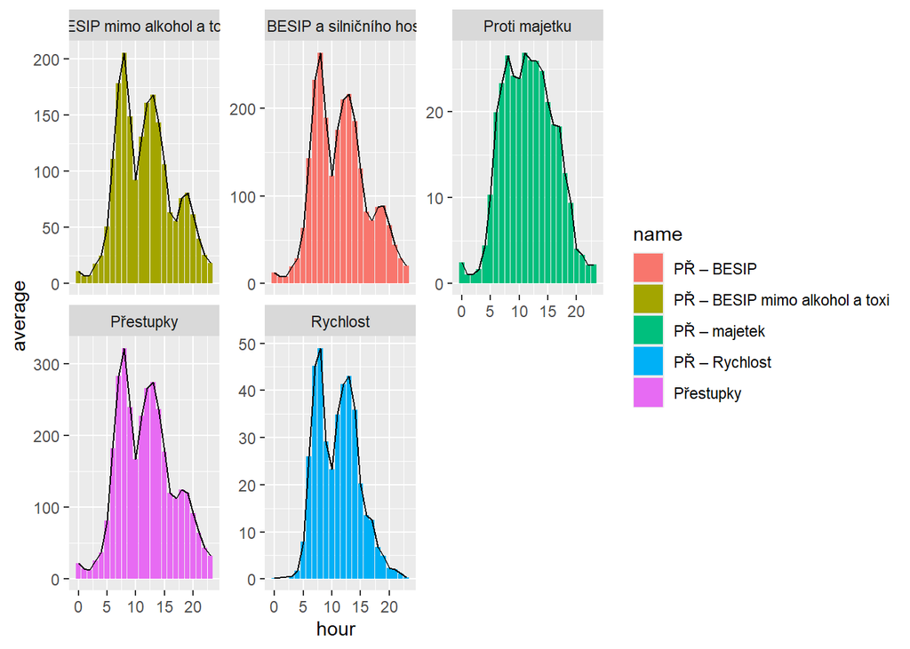

## Úkol 3

Využijte tabulky pro města Most, Praha a Poděbrady popisující trestnou činnost v těchto městech za rok 2023.

Tyto tabulky spojte do jedné tak, aby nová tabulka obsahovala všechny řádky a sloupce všech tří tabulek, a záznamy pro jednotlivá města byly rozlišeny kategoriální hodnotou nového sloupce `mesto`.

Pro vybrané následující typy trestních činů:

- `"KRÁDEŽE"`
- `"KRÁDEŽE VLOUPÁNÍM"`
- `"Rychlost"`
- `"PODVODY"`

spočtěte jejich četnost vztaženou na počet obyvatel a porovnejte tak jednotlivá města mezi sebou. Informaci o počtech obyvatel načtěte z tabulky `pocty_obyvatel.xlsx`.

Data ve výsledné tabulce zaokrouhlete na tři desetinná místa a vytvořte sloupcový graf, který bude popisovat relativní četnost vybraných trestních činů v jednotlivých městech.

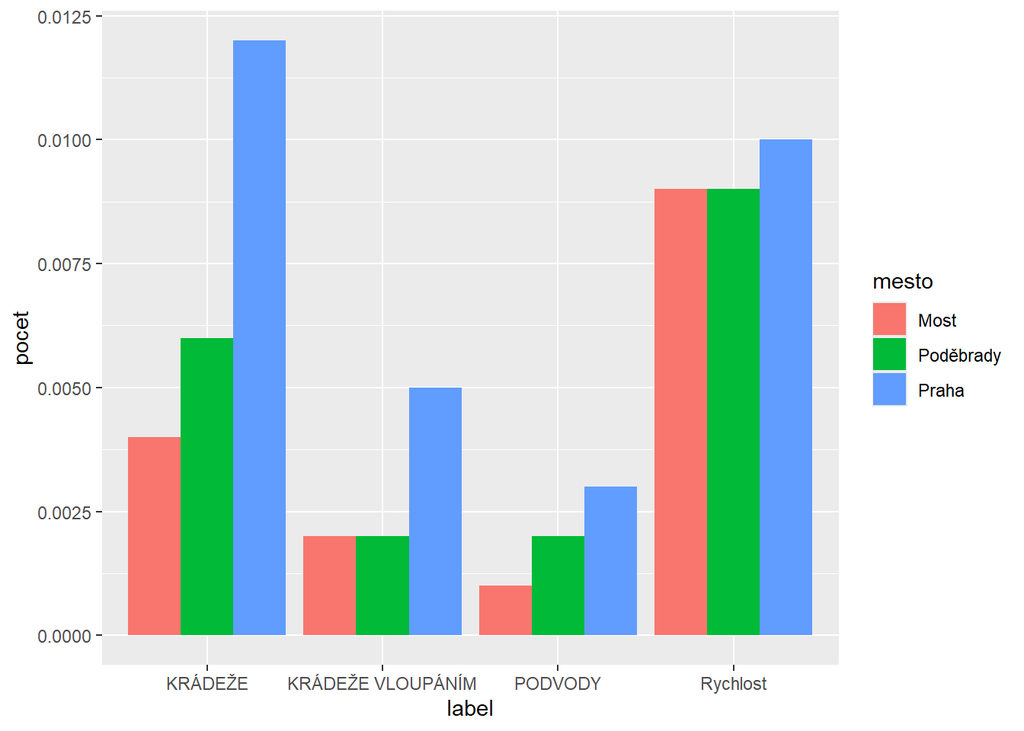

Výslednou tabulku vypište v následujícím formátu:

|  | mesto | pocet_obyvatel | KRÁDEŽE | KRÁDEŽE VLOUPÁNÍM | PODVODY | Rychlost |
| --- | --- | --- | --- | --- | --- | --- |
| 1 | Most | 66401 | 0.004 | 0.002 | 0.001 | 0.009 |
| 2 | Poděbrady | 14192 | 0.006 | 0.002 | 0.002 | 0.009 |
| 3 | Praha | 1309000 | 0.012 | 0.005 | 0.003 | 0.01 |